[figure not shown]

# Region level

### **England and Wales**

**Rate of proven offences (per 1,000) of children aged 10 to 17 years old rom 1st of April 2021 to 31st March 2022.**

<sup>Source: Bespoke analysis of the Youth Justice Application Framework (YJAF). Population is based on the 2021 mid-year population estimates (ONS) for 10-17 years old.</sup>

Note: Click on any region displays the actual value

[interactive chart not shown]

### **Table**

| Region | Number of proven offences | Population | Rate per 1,000 |
| --- | --- | --- | --- |
| East Midlands | 2644 | 456089 | 5.8 |
| Eastern | 3440 | 602705 | 5.7 |
| London | 5741 | 838036 | 6.9 |
| North East | 1469 | 241534 | 6.1 |
| North West | 3864 | 712704 | 5.4 |
| South East | 4265 | 892727 | 4.8 |
| South West | 2676 | 503766 | 5.3 |
| Wales | 1430 | 287455 | 5 |
| West Midlands | 2768 | 590970 | 4.7 |
| Yorkshire | 4229 | 524646 | 8.1 |

# YJS level

### **England and Wales**

**Rate of proven offences (per 1,000) of children aged 10 to 17 years old rom 1st of April 2021 to 31st March 2022.**

<sup>Source: Bespoke analysis of the Youth Justice Application Framework (YJAF). Population is based on the 2021 mid-year population estimates (ONS) for 10-17 years old.</sup>

Note: Click on any region displays the actual value

[interactive chart not shown]

### **Table**

| Region | Youth Justice Service | Number of proven offences | Population | Rate per 1,000 |
| --- | --- | --- | --- | --- |
| East Midlands | Derby | 262 | 26644 | 9.8 |
| East Midlands | Derbyshire | 310 | 70520 | 4.4 |
| East Midlands | Leicester City | 319 | 39944 | 8 |
| East Midlands | Leicestershire | 276 | 69456 | 4 |
| East Midlands | Lincolnshire | 375 | 67529 | 5.6 |
| East Midlands | Northamptonshire | 433 | 78386 | 5.5 |
| East Midlands | Nottingham | 378 | 29032 | 13 |
| East Midlands | Nottinghamshire | 291 | 74578 | 3.9 |
| Eastern | Bedfordshire | 183 | 46332 | 3.9 |
| Eastern | Cambridgeshire | 274 | 60564 | 4.5 |

[output cut: 144 more lines]

### **Distribution**

<sup>The boxplot shows the distribution of the data from individual YJSs and skewness through displaying the data quartiles. The black line indicates the median and the orange line the mean. Dots placed past the line edges indicate outliers, data points that differs significantly from other observations (two standard deviations above the average). A more detailed explanation of boxplots can be found [here](https://chartio.com/learn/charts/box-plot-complete-guide/). For example, looking at London, the boxplot indicates a range of data points between 2.6 to 10.7 (or to 15.8, taking into account the outlier data point). The left line shows the range of values up to the 25th percentile, the box shows that range of values between the 25th and the 75th percentile and the right line, data points over the 75th percentile. In this case the median is roughly the same as the mean, which indicates the data is normally distributed. An outlier is observed at 15.8, indicating this is a very high value compared to the rest of the data points in London.</sup>

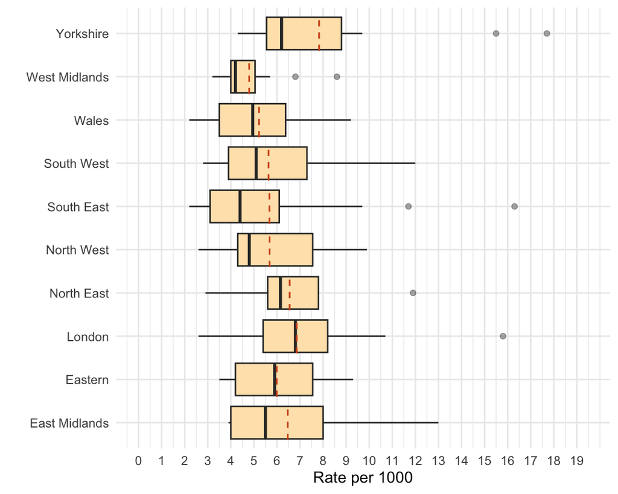